# Analysis Report

Ibrahim Abdullah

2022-11-18

# 1. Introduction

Established in 2016, Cyclistic is a bike-share offering service located in Chicago, USA. Cyclistic currently offers more than 5,800 bicycles that are geo-tracked and locked into a network of over 690 stations across Chicago. The bikes can be unlocked from one station and returned to another station in the system anytime. The Cyclistic team have recently concluded that annual memberships are more profitable than casual riders. Furthermore, the team have noted that while 30% of users use the bikes for their work commute, the majority of Cyclistic users ride for leisure. This report will assess how existing Cyclistic causal riders can be encouraged to convert to annual memberships.

# 2. Data Processing

Due to the large file sizes, R has been used to clean and process the large datasets.

The data has been cleaned by way of merging all 4 quarterly datasets into one, deleting incomplete data elements, removing test station results, removing negative ride lengths and summarising the dataset by date and time variables. The full data cleaning process has been documented in “Data Cleaning”.

The cleaned dataset has been saved under the file name “all_trips_cleaned”.

```r
library(tidyverse)
library(data.table)
```

```r
library(ggplot2)
library(viridis)
all_trips_clean <- fread("C:\\Users\\Ibrahim\\Desktop\\Google Data Analytics Course\\Capstone Projects\\Cyclist Case Study\\all_trips_clean.csv")
```

# 3. Analysis

## (i) Most Popular Time of Year

```r
# Arrange weekdays in order
all_trips_clean$day_of_week <- ordered(
  all_trips_clean$day_of_week,
  levels = c("Monday", "Tuesday", "Wednesday", "Thursday", "Friday", "Saturday", "Sunday")
)

#data frame to summarize number of trips by date
heat_map_data <- all_trips_clean %>%
  select(YMD, day_of_week, week, year) %>%
  group_by(YMD) %>% mutate(numtrips = n()) %>%
  distinct(YMD, .keep_all = TRUE)
```

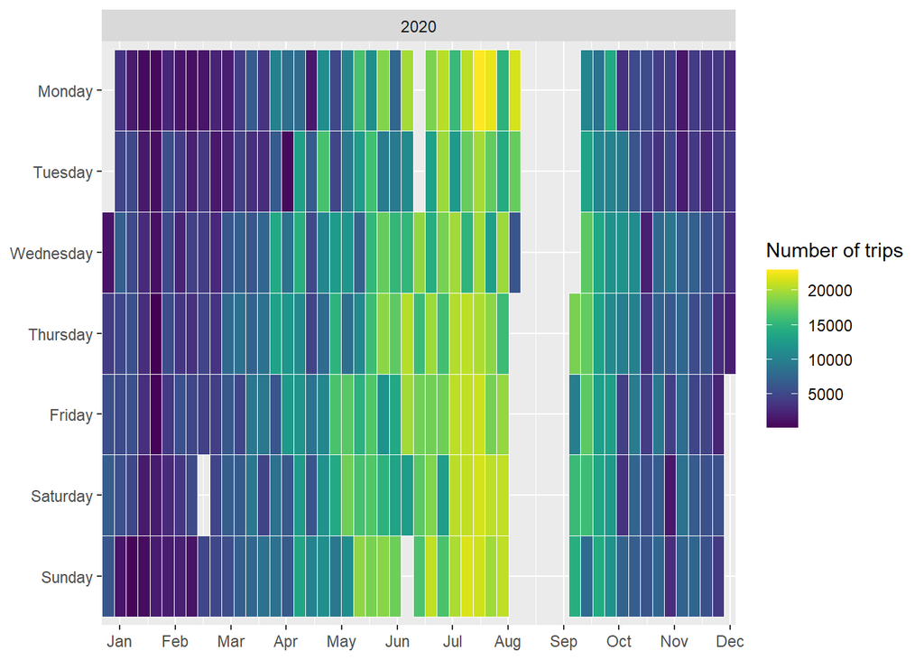

```r
# Create heat map to show most popular time of year

P1 <- ggplot(heat_map_data, aes(x = week, y = day_of_week,
                                fill = numtrips)) +
  scale_fill_viridis(option = "D", direction = 1,
                     name = "Number of trips") +
  geom_tile(colour = "white",
            na.rm = FALSE) + facet_wrap(
              "year", ncol = 1) +
  scale_y_discrete(limits = rev) + scale_x_continuous(
    expand = c(0, 0),
    breaks = seq(1, 52, length = 12),
    labels = c("Jan", "Feb", "Mar", "Apr", "May", "Jun",
               "Jul", "Aug", "Sep", "Oct", "Nov", "Dec")
    ) + theme(axis.title = element_blank())

P1
```

## (ii) Most Popular Rider Type

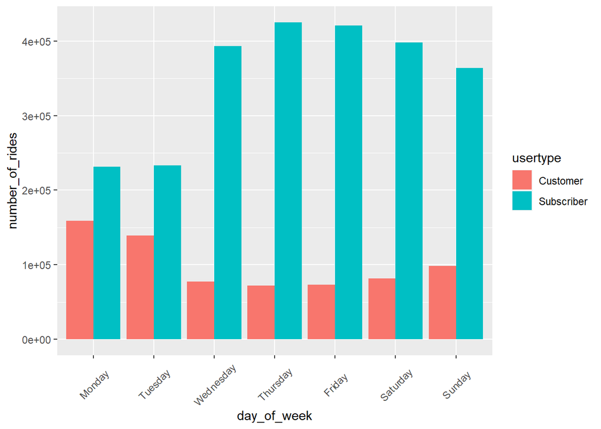

```r
# Number of rides by rider type
all_trips_clean %>% group_by(usertype, day_of_week) %>%
  summarise(number_of_rides = n(),
            average_duration=mean(ride_length)) %>%
  arrange(usertype, day_of_week) %>%
  ggplot(aes(x = day_of_week, y = number_of_rides, fill = usertype)) + geom_col(position = "dodge") + theme(axis.text.x = element_text(angle = 45, vjust = 0.5))
```

## (iii) Average Ride Duration

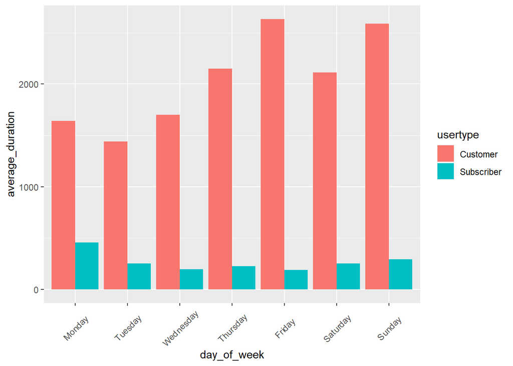

```r
# Average duration visualization
all_trips_clean %>% group_by(usertype, day_of_week) %>%
  summarise(number_of_rides = n(), average_duration = mean(ride_length)) %>% arrange(usertype, day_of_week) %>%
  ggplot(aes(x=day_of_week, y=average_duration, fill =usertype)) + geom_col(position = "dodge") + theme(axis.text.x = element_text(angle = 45, vjust = 0.5))
```

#4. Descriptive Analysis

```r
# Calculate mean, median, mode
getmode <- function(v) {
  uniqv <- unique(v)
  uniqv[which.max(tabulate(match(v, uniqv)))]
}

all_trips_clean$ToD_convert <- as.POSIXct(all_trips_clean$ToD, format = "%H:%M:%S")


# Create a summary data frame
statistic <- all_trips_clean %>%
  group_by(usertype) %>% summarise(
    avg_ride_length_mins = (mean(ride_length, na.rm = TRUE))/60,
    mode_day_of_week = getmode(day_of_week),
    mode_month = getmode(month),
    mode_time_of_day = getmode(ToD),
    avg_time_of_day = format(mean(ToD_convert, na.rm = TRUE), "%H:%M:%S")
  )
```

```r
library(knitr)
kable(head(statistic))
```

| usertype | avg_ride_length_mins | mode_day_of_week | mode_month | mode_time_of_day | avg_time_of_day |
| --- | --- | --- | --- | --- | --- |
| Customer | 32.534471 | Monday | 7 | 19:17:05 | 19:14:58 |
| Subscriber | 4.234602 | Thursday | 7 | 19:17:05 | 19:14:01 |

#5. Recommendations

As per the analysis performed above, following strategies can be implemented by Cyclistic:-

*1. Digital marketing campaign showing Cyclistic bikes being used in a Chicago resident’s everyday life*

*2. Advertising price benefit of annual memberships*

*3. Targeted advertisement to casual riders focusing on digital campaigns emphasizing the health benefit of using bikes for daily commute*